# Image Analysis Vignette

Ilaria Billato, Marcel Ramos, Sean Davis, Mohamed Omar, Lucio R. Queiroz, Luigi Marchionni, Hervé Pagès, Vince J. Carey, Levi Waldron, Sehyun Oh, Davide Risso and Chiara Romualdi

Department of Biology, University of Padova, Padova, Italy  
Graduate School of Public Health and Health Policy, City University of New York, New York, NY, USA  
Department of Biomedical Informatics, University of Colorado Anschutz Medical Campus, Aurora, USA  
Cedars-Sinai Medical Center  
Department of Pathology and Laboratory Medicine, Weill Cornell Medicine, New York, NY, USA  
Fred Hutchinson Cancer Research Center, Seattle, WA, USA  
Channing Division of Network Medicine, Brigham And Women’s Hospital, Boston, MA, USA  
Department of Statistical Sciences, University of Padova, Padova, Italy

ilaria.billato@phd.unipd.it

06 Mar 2025

#### Abstract

This vignette outlines a workflow for analyzing high-resolution histopathological images and features from The Cancer Genome Atlas (TCGA). It integrates Python-based tools with R/Bioconductor to extract, store, and analyze features like cell counts and spatial patterns. The imageTCGA Shiny app enables interactive exploration, filtering, and visualization of data. Case studies demonstrate the repository’s potential for advancing cancer research through integrated histopathology and multi-omics analyses.

# 1 Version Info

**R version**: R version 4.4.3 (2025-02-28)  
**Bioconductor version**: 3.20  
**Package version**: 1.40.0

# 2 Introduction

This vignette provides an overview of the workflow for analyzing high-resolution diagnostic images and features derived from TCGA datasets, using modern computational tools. This project aims to bridge the gap between Python-based image analysis tools and the R/Bioconductor ecosystem, enabling seamless multimodal analyses that integrate histopathological image features with genomic and transcriptomic data. By creating robust workflows and a comprehensive repository of features extracted from The Cancer Genome Atlas (TCGA), the project addresses computational challenges in digital pathology and supports advanced cancer research.

# 3 TCGA Data

```r
## Example GDCdatacommon code for downloading images
## Make sure BiocManager is installed
if (!require("BiocManager", quietly = TRUE))
    install.packages("BiocManager")

## Make sure GenomicDataCommons is installed
# BiocManager::install("GenomicDataCommons")
library("GenomicDataCommons")

# File IDs to download
file_ids <- c(
# Insert your file IDs here
  )

# Download files
lapply(file_ids, gdcdata)
```

One or more ‘diagnostic’ formalin-fixed paraffin-embedded (FFPE) slides are submitted to the BCR by the TSS for confirmation of histological diagnosis. These diagnostic slides originate from the same tumour, but their relationship to the material submitted for genomic analysis is unknown. The frozen sections provide the best representation of the tissue contents reflected in genomic signatures. However, the freezing artefacts in these slides can confound routine pathological examination or image analysis algorithms. Cooper et al. (2018)

# 4 imageTCGA shiny app

The `imageTCGA` is a Shiny application package designed for interactive browsing, visualization, and analysis of the extracted features from TCGA diagnostic images.

Available on github: https://github.com/billila/imageTCGA

The main features of this Shiny dashboard include:

- **Filtering the dataset** based on:
  - Project ID
  - Case ID
  - Sample Type
  - Source Site
  - State criteria
- **R code generation** for downloading filtered datasets.
- **Exploration of image features** extracted by HoVerNet and Prov-GigaPath.
- **Visualizations**:
  - Heatmaps for the relationship between categorical variables.
  - Interactive sample distribution map for source site locations using Leaflet.
  - Links to interactive image viewers (e.g., QuPath, napari, ImageJ).

# 5 HoVer-Net

## 5.1 Introduction

HoVer-Net Graham et al. (2019) is a state-of-the-art deep learning model for cell segmentation and classification. The input to HoVer-Net is `.svs` format images, typically derived from H&E-stained slides. HoVer-Net is based on the **Pancancer Atlas** and leverages modern neural network architectures to achieve precise segmentation and classification.

## 5.2 Outputs

### 5.2.1 JSON Structure Explanation

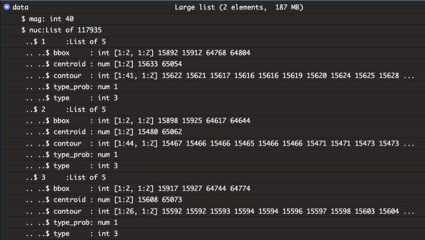

Example of HoVer-Net Output

- **mag**: This typically indicates the magnification level of the slide. In this case, it’s set to 40.
- **nuc**: This is a dictionary containing the detected nuclei. Each key (like 1, 2, etc.) represents a unique nucleus detected in the image.

Each nucleus entry contains:

- **bbox**: The bounding box coordinates of the nucleus, represented as two points (top-left and bottom-right).
- **centroid**: The coordinates of the centroid of the nucleus, which is the center point calculated based on the contour.
- **contour**: A list of points that outline the shape of the nucleus. This is useful for visualizing the exact shape and boundaries of the detected nucleus.
- **type_prob**: The probability associated with the type of the nucleus, indicating the model’s confidence in its classification.
- **type**: This typically represents the class label assigned to the nucleus (e.g., different types of cells or states).

#### 5.2.1.1 Example Interpretation

For example, for nucleus “1”:

- **Bounding Box**: The nucleus is located within the coordinates given by `[[15892, 64768], [15912, 64804]]`.
- **Centroid**: The center of this nucleus is at `[15633, 65054]`.
- **Contour**: The shape of the nucleus is defined by the series of points listed in the “contour” array.
- **Type Probability**: The model is very confident (close to 1.0) that this is of type 3.
- **Type**: Type 3. HoVer-Net was used on patches from each class separately to segment and classify the nuclei into 5 different types: benign epithelial, neoplastic, inflammatory/immune, necrotic, and stromal.

All computations for HoVer-Net were performed on the **Jetstream Cloud Platform**. Follow this link for setting a reproducible enviroment: https://github.com/hpages/hovernethelp

## 5.3 Feature Extraction

The extracted features include:

- **Cell counts**
- **Cell type distributions**
- **Spatial patterns**

Features are stored in an `.h5ad` format for downstream single-cell and spatial analyses.

# 6 Prov-Giga Path

## 6.1 Introduction

Prov-Giga Path Xu et al. (2024) is a framework designed for embedding diagnostic image data into lower-dimensional spaces for visualization and analysis.

## 6.2 Embeddings

Embeddings are generated using unsupervised learning techniques, optimized for high-resolution pathology data. These embeddings represent a novel class of non-human-readable features and capture high-dimensional spatial and structural relationships in histopathological images.

# 7 Case Study

## 7.1 Purity and Ploidy

### 7.1.1 Purity

Data for tumor purity were downloaded from Aran, Sirota, and Butte (2015). Tumour purity is the proportion of cancer cells in the admixture. Until recently, it was estimated by a pathologist, primarily by visual or image analysis of tumour cells. With the advancement of genomic technologies, many new computational methods have arisen to infer tumour purity. These methods make estimates using different types of genomic information, such as gene expression, somatic copy-number variation, somatic mutations, and DNA methylation.

Aran, Sirota, and Butte (2015) compared purity estimates using four methods:

- ESTIMATE, which uses gene expression profiles of 141 immune genes and 141 stromal genes.
- ABSOLUTE, which relies on somatic copy-number data (estimates were available for only 11 cancer types).
- LUMP (Leukocytes Unmethylation for Purity), which averages 44 non-methylated immune-specific CpG sites.
- IHC, estimated through image analysis of H&E-stained slides.
- CPE (Consensus Measurement of Purity Estimations), which represents the median purity level after normalizing estimates from all methods to ensure equal means and standard deviations (75.3±18.9%). Since some samples lacked measurements from all four methods, CPE was restricted to samples with at least two available measurements.

From the Hovernet output, we compute purity as the ratio of nuclei classified as neoplastic to the total number of nuclei in an image. This count is obtained from the JSON output.

### 7.1.2 Ploidy

We want to correlate these metrics with imaging features to understand tumor heterogeneity.

## 7.3 Case Study 2: Prostate Cancer

# 8 TCIA Data

The TCIA (The Cancer Imaging Archive) is a large archive of medical images of cancer available for public download. It provides a wealth of imaging data, including various modalities such as CT, MRI, and PET scans and histopathological images along with associated clinical data.

## 8.1 TCIAAPI package

The `TCIAAPI` package provides an interface to the Cancer Imaging Archive (TCIA) API. The TCIA API allows users to programmatically access the TCIA data. The package provides functions to obtain an access token, download SVS images, and retrieve metadata from the TCIA API.

Github repo: https://github.com/billila/TCIAAPI

```r
## Currently, the package only resides on GitHub.

if (!require("BiocManager", quietly = TRUE))
    install.packages("BiocManager")

BiocManager::install("billila/TCIAAPI")

library(TCIAAPI)

## to retrieve the access token from the TCIA API
tcia_access_token() |> httr2::obfuscate()

## Information on SVS Images
svsinfo <- tcia_svs_info("311781")
svsinfo |> head(3L)

## Download URL
svsinfo[["field_wsiimage"]][[1L]][["url"]]

## Download SVS Images
tcia_svs_download("311781")
```

# 9 Author contributions

# 10 Competing interests

No competing interests were disclosed.

# 11 Grant information

# 12 Acknowledgments

# References

Aran, Dvir, Marina Sirota, and Atul J Butte. 2015. “Systematic Pan-Cancer Analysis of Tumour Purity.” *Nature Communications* 6 (1): 8971.

Cooper, Lee AD, Elizabeth G Demicco, Joel H Saltz, Reid T Powell, Arvind Rao, and Alexander J Lazar. 2018. “PanCancer Insights from the Cancer Genome Atlas: The Pathologist’s Perspective.” *The Journal of Pathology* 244 (5): 512–24.

Graham, Simon, Quoc Dang Vu, Shan E Ahmed Raza, Ayesha Azam, Yee Wah Tsang, Jin Tae Kwak, and Nasir Rajpoot. 2019. “Hover-Net: Simultaneous Segmentation and Classification of Nuclei in Multi-Tissue Histology Images.” *Medical Image Analysis* 58: 101563.

Oh, Sehyun, Ludwig Geistlinger, Marcel Ramos, Martin Morgan, Levi Waldron, and Markus Riester. 2020. “Reliable Analysis of Clinical Tumor-Only Whole-Exome Sequencing Data.” *JCO Clinical Cancer Informatics* 4: 321–35.

Xu, Hanwen, Naoto Usuyama, Jaspreet Bagga, Sheng Zhang, Rajesh Rao, Tristan Naumann, Cliff Wong, et al. 2024. “A Whole-Slide Foundation Model for Digital Pathology from Real-World Data.” *Nature*, 1–8.